## Homework Assignment 11

### Preliminaries

- Directories
  - COURSE/homework/
  - COURSE/homework/hw11/
  - COURSE/data/
  - COURSE/scripts/
- Files
  - COURSE/homework/hw11/hw11.Rmd
  - COURSE/data/boston-marathon-data.csv
  - COURSE/data/dugong.csv
  - COURSE/scripts/viridis.R
  - COURSE/scripts/ggprob.R

### Data

- Some problems use a new data set on lengths and ages of a sample of dugongs in the file `dugong.csv`.
- Additional problems use the Boston Marathon data in the file `boston-marathon-data.csv`. This file is a transformed version of the raw data we used in class and has data for all runners who completed the race in 2010 and 2011. The variable `Time` is the sum of the times from the different portions of the race, each of which begins with “K”.

### Aims

- Practice regression

## Problems

### 1.

In a regression problem to estimate $y$ from explanatory variable $x$ from a sample of size $n$, partial summary information is $\bar{x} = 20$ and $\bar{y} = 100$. Regardless of the values of other summary statistics, what is the value the predicted value $\hat{y}$ at a point where $x = 20$? Briefly explain.

> x and y bar are the averrage of the xs and ys and they lay on the regression line. Hence, we are looking for y hat which is necessarily on the line, and I can conclude that the value of yhat is 100.

### 2.

In a regression problem to estimate $y$ from explanatory variable $x$ from a sample of size $n$, partial summary information is $\bar{x} = 20$, $s_x = 5$, $\bar{y} = 100$, and $s_y = 15$. Which of the following values are possible values for the predicted value $\hat{y}$ when the explanatory variable has value $x = 30$? Briefly explain.

**(a)** 50  
**(b)** 70  
**(c)** 100  
**(d)** 120  
**(e)** 150

> The answer is b, c and d. Since we dont know whether the line has positive or negative slope, we need to consider both cases. x = 30 is two standard deviations from xmean=20, hence we assume that yhat varies also 2 standard deviations which would be +- 2*15. So the range of correct options would be between 70 and 130.

Problems 3–6 are based on the data set in the file *dugong.csv* which relates age (in years) and length (in meters) of a sample of 27 dugongs, a type of marine mammal.

Credit: The *dugong.csv* file is from Data8 at UC-Berkeley.

### 3.

Read the dugong data. Create a scatter plot with `length` on the x-axis and `age` on the y-axis.

- Add descriptive axis labels (include units of measurement) and a title.
- Using `geom_smooth()`, add the least-squares line to your plot.

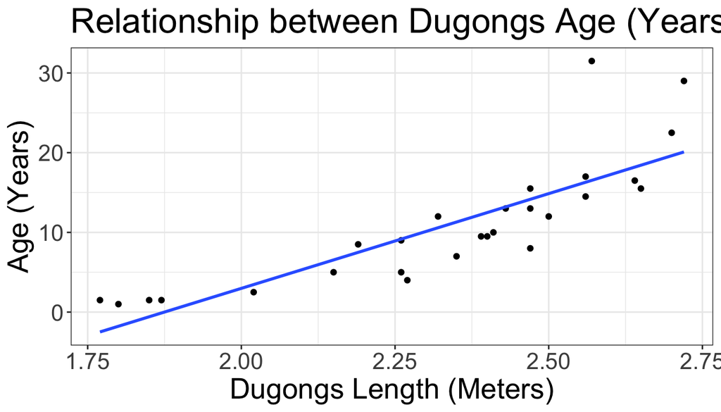

```r
data = read_csv("../../data/dugong.csv")
#data

ggplot(data, aes(x = Length, y = Age)) +
  geom_point() +
  xlab("Dugongs Length (Meters)") +
  ylab("Age (Years)") +
  ggtitle("Relationship between Dugongs Age (Years) and Length (Meters)") +
  geom_smooth(se = FALSE, method = "lm") +
  theme_bw() +
  theme(text = element_text(size = 20))
```

### 4.

-4a. Using the dugong data, calculate the sample means, sample standard deviations, and correlation coefficient of the variables `age` and `length`.

```r
data2 = data %>%
  summarise(meanAge = mean(Age), meanLength = mean(Length), sdAge = sd(Age), sdLength = sd(Length), corelationCoefficient = cor(Length, Age))
data2
```

```
## # A tibble: 1 × 5
##   meanAge meanLength sdAge sdLength corelationCoefficient
##     <dbl>      <dbl> <dbl>    <dbl>                 <dbl>
## 1    10.9       2.34  7.87    0.275                 0.830
```

-4b. Using formulas from lecture, calculate the slope and intercept of the least squares regressions line to predict age with length.

```r
beta_hat_1 = data2$corelationCoefficient * data2$sdAge / data2$sdLength
beta_hat_0 = data2$meanAge - beta_hat_1 * data2$meanLength

c(beta_hat_1, beta_hat_0)
```

```
## [1]  23.77168 -44.56683
```

-4c. Use the dugong data and the functions `lm()` and `coef()` to calculate the slope and intercept of the least squares regression line of age against length (use length to predict age).

```r
model_object = lm(data$Age ~ data$Length)
model_object
```

```
##
## Call:
## lm(formula = data$Age ~ data$Length)
##
## Coefficients:
## (Intercept)  data$Length
##      -44.57        23.77
```

```r
estimates = coef(model_object)
estimates
```

```
## (Intercept) data$Length
##   -44.56683    23.77168
```

-4d. Verify that you get the same values for the slope and mean in 4b and 4c.

> Yes I get the same values. The line equation is: y = 23.77168 * x - 44.56683

### 5.

-5a. Add columns with the predicted values and residuals to the dugong data set. *(You can use* **modelr** *functions or just use `mutate()` and calculate these values directly.)* Print the first 10 rows of this modified data set

```r
resid(model_object)
```

```
##          1          2          3          4          5          6          7
##  2.7778060  2.0892220  1.6137885  3.9909564 -0.9519634 -5.3948831 -1.5422817
##          8          9         10         11         12         13         14
## -4.1571664 -4.2966175 -6.1492190  1.0068512 -0.1571664 -2.9852014 -2.7474846
##         15         16         17         18         19         20         21
## -2.7229182 -2.8623693  1.4165329 -0.1983518 -1.1492190 -1.7886701 -2.9281212
##         22         23         24         25         26         27
##  1.3507810 -1.6904044  0.7113299  2.8832949  8.9078613 14.9736131
```

```r
data %>%
  mutate(resid = resid(model_object)) %>%
  head(10)
```

```
## # A tibble: 10 × 3
##    Length   Age  resid
##     <dbl> <dbl>  <dbl>
##  1   1.8    1    2.78
##  2   1.85   1.5  2.09
##  3   1.87   1.5  1.61
##  4   1.77   1.5  3.99
##  5   2.02   2.5 -0.952
##  6   2.27   4   -5.39
##  7   2.15   5   -1.54
##  8   2.26   5   -4.16
##  9   2.35   7   -4.30
## 10   2.47   8   -6.15
```

-5b. Plot the residuals versus length.

- Add a horizontal line at $y=0$ and appropriate labels on each axis.

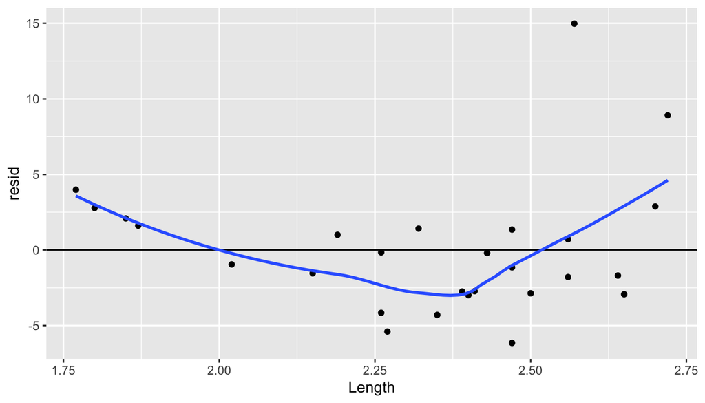

```r
dugong_with_residuals = data %>%
  add_residuals(model_object)
# dugong_with_residuals

ggplot(dugong_with_residuals, aes(x = Length, y = resid)) +
  geom_point() +
  geom_hline(yintercept = 0) +
  geom_smooth(se = F)
```

-5c. Describe what the residual plot suggests about the appropriateness of using simple linear regression to predict age from length of dugongs.

> Since there is visual non linear (quadratic function) line, I can note that linear function is not appropriate to approximate the trend of the lines. One more note is that sigma is not constant for different lengths. The residual plot provides insight into whether the residuals are randomly dispersed around the horizontal line at y = 0 or if they display any systematic pattern. Since there is visual non linear function.

### 6.

-6a. Print the summary of the fitted regression model using `lm()` from problem 4.

```r
summary(model_object)
```

```
##
## Call:
## lm(formula = data$Age ~ data$Length)
##
## Residuals:
##    Min     1Q Median     3Q    Max
## -6.149 -2.805 -0.952  1.515 14.974
##
## Coefficients:
##             Estimate Std. Error t value Pr(>|t|)
## (Intercept)  -44.567      7.521  -5.926 3.48e-06 ***
## data$Length   23.772      3.199   7.430 8.79e-08 ***
## ---
## Signif. codes:  0 '***' 0.001 '**' 0.01 '*' 0.05 '.' 0.1 ' ' 1
##
## Residual standard error: 4.48 on 25 degrees of freedom
## Multiple R-squared:  0.6883, Adjusted R-squared:  0.6758
## F-statistic: 55.21 on 1 and 25 DF,  p-value: 8.794e-08
```

- The simple linear regression model for $Y_i$ conditional on the values of $X_i = x_i$ is

$$Y_i = \beta_0 + \beta_1 x_i + \varepsilon_i, \quad \text{for $i = 1,
\ldots,n$}$$

where $\varepsilon_i \sim \text{Normal}(0, \sigma)$ for some parameter $\sigma > 0$.

- The parameter $\sigma$ is the unknown population standard deviation of the typical distance between a point $Y_i$ and its expected value, $\mathsf{E}(Y_i \mid X_i = x_i) = \beta_0 + \beta_1 x_i$.

-6b. Use the function `sigma()` on the fitted regression object (what you created with `lm()`) to extract the numerical value of the estimate of $\sigma$. Check that this value matches the printed value of the model summary in 6a. Print this value.

```r
sigma(model_object)
```

```
## [1] 4.480469
```

- The numerical estimate of $\sigma$ here is not quite the standard deviation of the residuals because the denominator is $n-2$, the degrees of freedom in simple linear regression, instead of $n-1$, the degrees of freedom from a single numerical sample.

-6c. Use the column of residuals in the augments data set `dugong` and verify that:

- the mean of the residuals equals zero (numerically, it might be very close, but not exactly equal, to zero).
- you arrive at the numerical estimate of $\sigma$ by calculating

$$\sqrt{ \frac{\sum_{i=1}^n (y_i - \hat{y}_i)^2}{n-2} }$$

where the $i$th residual is $y_i - \hat{y}_i$.

```r
res = dugong_with_residuals$resid
n = nrow(dugong_with_residuals)

sqrt(sum(res^2)/(n-2))
```

```
## [1] 4.480469
```

- Problems 7–8 use the cleaned Boston Marathon data in `boston-marathon-data.csv`.

### 7.

- Read in the Boston marathon data from the file `boston-marathon-data.csv`.

```r
boston_data = read_csv("../../data/boston-marathon-data.csv")
boston_data
```

```
## # A tibble: 46,583 × 15
##    BibNum  Year Sex     Age Age_Range  Time `K0-5` `K5-10` `K10-15` `K15-20`
##     <dbl> <dbl> <chr> <dbl> <chr>     <dbl>  <dbl>   <dbl>    <dbl>    <dbl>
##  1      1  2010 male     29 18-34      129.   15.1    15.1     14.8     15.2
##  2      3  2010 male     27 18-34      129.   14.9    15.2     15.0     15.0
##  3      5  2010 male     21 18-34      141.   14.9    15.2     14.8     15.2
##  4      6  2010 male     21 18-34      126.   14.9    15.2     14.8     15.2
##  5      8  2010 male     25 18-34      135.   14.9    15.2     14.9     15.2
##  6      9  2010 male     27 18-34      135.   14.9    15.2     14.8     15.2
##  7     12  2010 male     28 18-34      127.   14.9    15.2     14.9     15.2
##  8     14  2010 male     31 18-34      131.   14.9    15.2     14.9     15.5
##  9     15  2010 male     32 18-34      132.   14.9    15.2     15.8     15.6
## 10     16  2010 male     23 18-34      157    14.9    15.2     14.9     15.1
## # ℹ 46,573 more rows
## # ℹ 5 more variables: `K20-25` <dbl>, `K25-30` <dbl>, `K30-35` <dbl>,
## #   `K35-40` <dbl>, `K40-Fin` <dbl>
```

-7a. Create a scatter plots of `Time` versus `Age` for the female runners in 2010.

- Add a straight regression line
- Add a smooth curve
- As there are so many points, you may set `alpha` to a value less than one inside of `geom_point()` to lessen the effects of over-plotting.

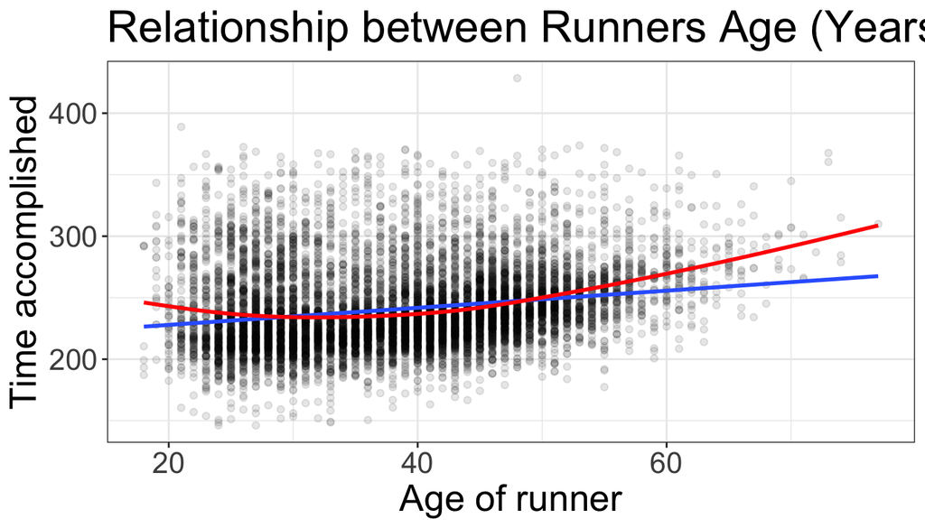

```r
boston_data2 = boston_data %>%
  filter(Sex == "female" & Year == 2010)


ggplot(boston_data2, aes(x = Age, y = Time)) +
  geom_point(alpha = 1/10) +
  xlab("Age of runner") +
  ylab("Time accomplished") +
  ggtitle("Relationship between Runners Age (Years) and Time accomplishjed (Minutes) ") +
  geom_smooth(se = FALSE, method = "lm") + # Recall: se = FALSE takes away the "ribbon", method = "lm" makes the line straight. More on these arguments later in this lecture!
  theme_bw() +
  theme(text = element_text(size = 20)) +
  geom_smooth(se = F, color = "red")
```

-7b. Make a residual plot of the residuals versus `Age`.

- Include a horizontal line at $y=0$
- Include a smooth curve through the residuals

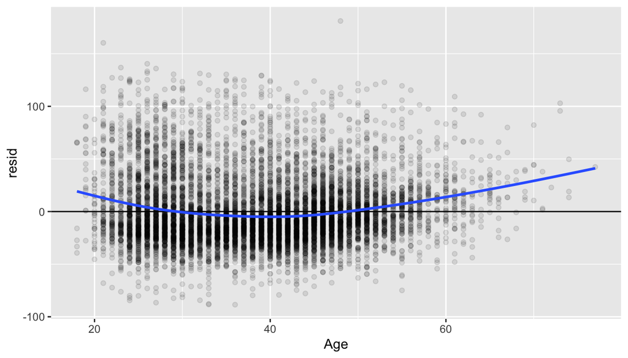

```r
model_object2 = lm(Time ~ Age, boston_data2)
#model_object2

boston_data2 = boston_data2 %>%
  add_residuals(model_object2)


ggplot(boston_data2, aes(x = Age, y = resid)) +
  geom_point(alpha = 1/10) +
  geom_hline(yintercept = 0) +
  geom_smooth(se = F)
```

-7c. Make a density plot of the residuals.

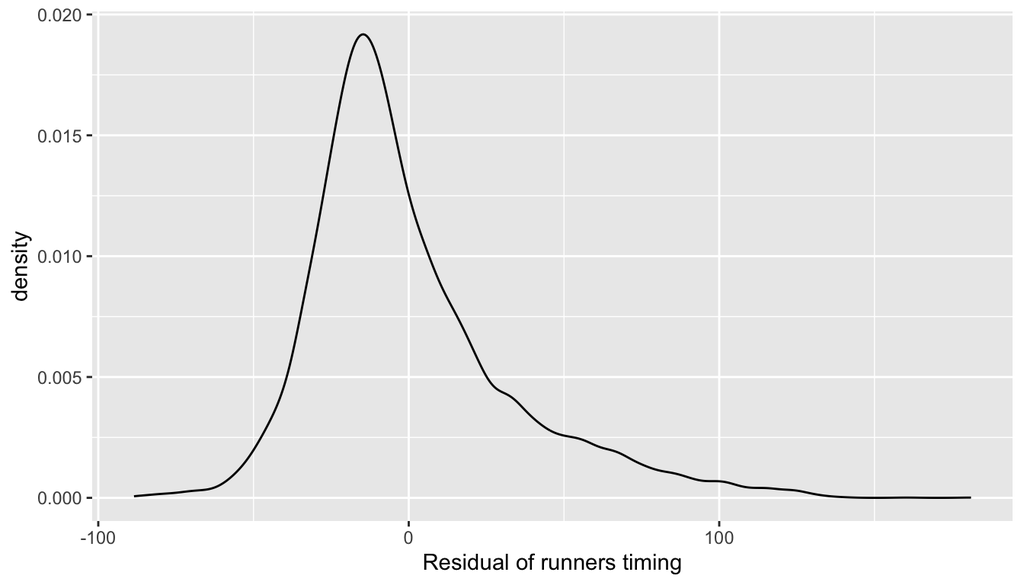

```r
ggplot(boston_data2, aes(x = resid)) +
  geom_density() +
  xlab("Residual of runners timing")
```

### 8.

Examine the residual plots from the previous problem.

-8b. Is there evidence that the standard deviation of the residuals varies substantially with changes in age?

> There is no evidence showing that the standard deviastion of the residuals varies substantially with the change in age.

-8c. Is there evidence that the error distribution for individual residuals is not symmetric?

> Yes there is evidence showing that the error distributon for indicidual residuals is not symmetric. The density graph is right skewed.